# The Relationship Between Alcohol Consumption and Additional Factors with Physical Health

## Abstract

The research question attempted to answer was *“How much alcohol consumed start to affect a person’s health? What other factors can be considered alongside alcohol in affect to a person’s health?”* This focuses on individuals who took a survey provided by the Centers for Disease Control and Prevention (CDC) with data from 2017-2020. This research topic is important due to how popular alcohol culture is, not only within the United States, but globally.

Multiple data sets were used for this research including demographics, alcohol use, and blood pressure and cholesterol. The data sets were merged together into one and had their columns renamed due to the provided labels being unclear to what they stood for. Two main variables had been used as predictors for the condition of an individual’s blood pressure and cholesterol level: consumption of alcohol and the gender of an individual.

## Background

In the United States, over 86 percent of adults admit to having at least one drink of alcohol throughout their life. Annually, over 140,000 people die from alcohol-related causes. In the United States alone, alcohol is the fourth-leading preventable cause of death. Alcohol-related deaths are consisted of many factors, however some of the most common are hypertension and kidney failure. Health problems such as the ones listed can lead to other conditions and issues as well, such as heart failure and more.

The data sets used come from the Centers for Disease Control and Prevention (CDC)’s website. It is from the from the 2017-2020 Pre Pandemic National Health and Nutrition Examination Survey (NHANES) Questionnaire. All information is from before the COVID-19 pandemic as stated so data may be different from current day situations. Unfortunately, there was no data from 2020-2023 available to compare. The data sets used from the surveys were demographics, alcohol use, and blood pressure and cholesterol.

## Results

### Figure 1

**Average Alcohol Consumption Based on Gender**

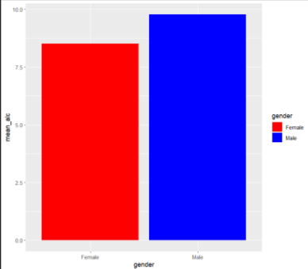

Figure 1 shows the relationship between a person’s gender and the amount of alcohol consumed. Males consume more alcohol on average (taken from the past 12 months of taking the survey)/

### Figure 2

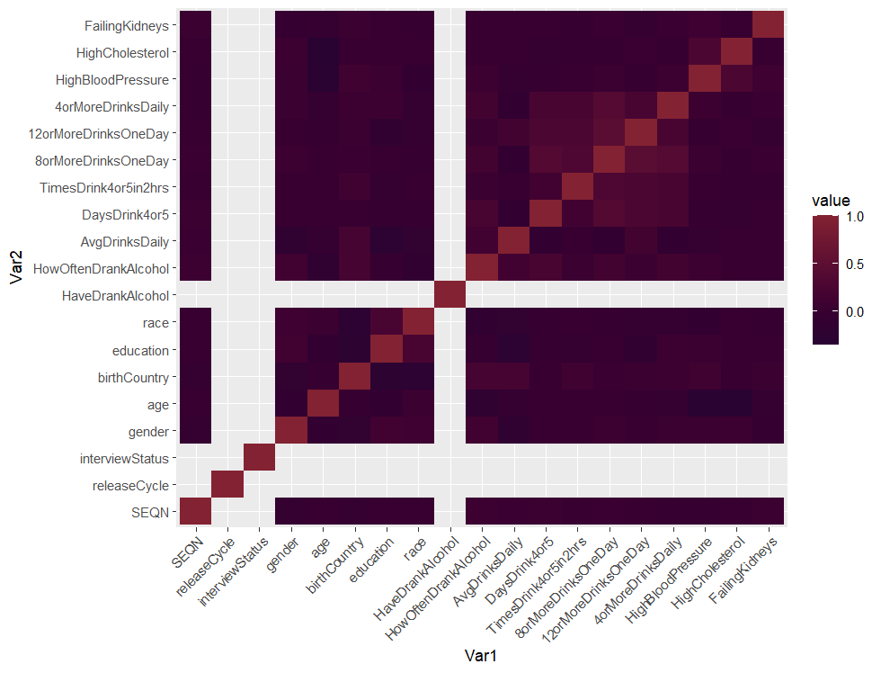

Figure 2 displays a correlation plot with all the variables in the dataset. It is not too clear on what factors are really correlated. So I decided to compare certain factors using bar graphs to find more specific correlations closer to what my research question sought to understand. This is shown in Figures 3 and 4.

### Figure 3

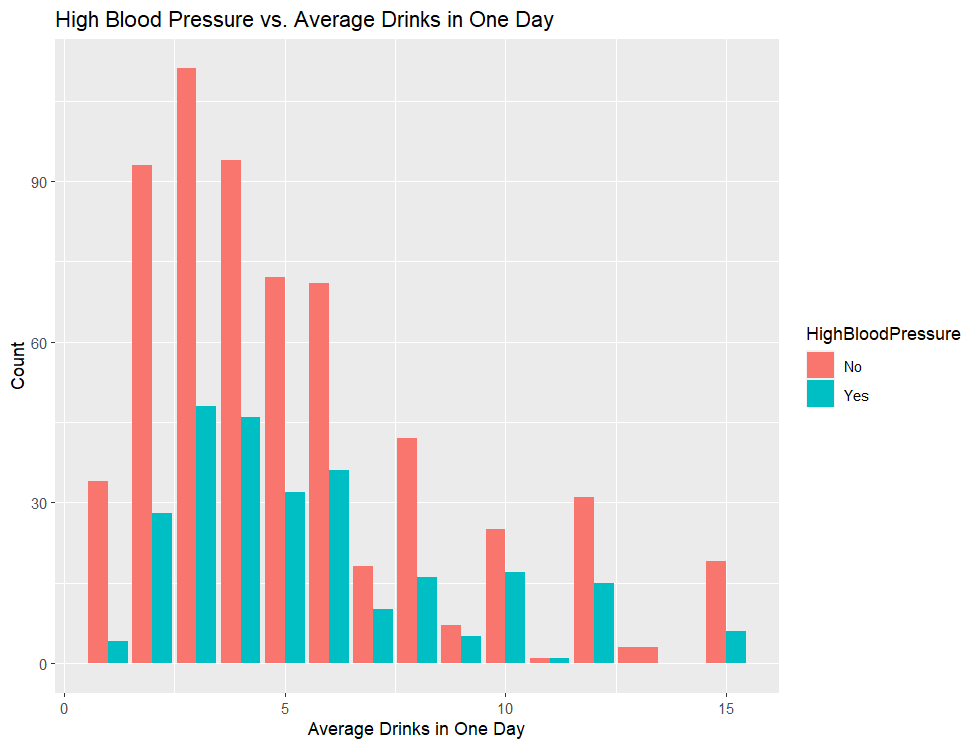

### Figure 4

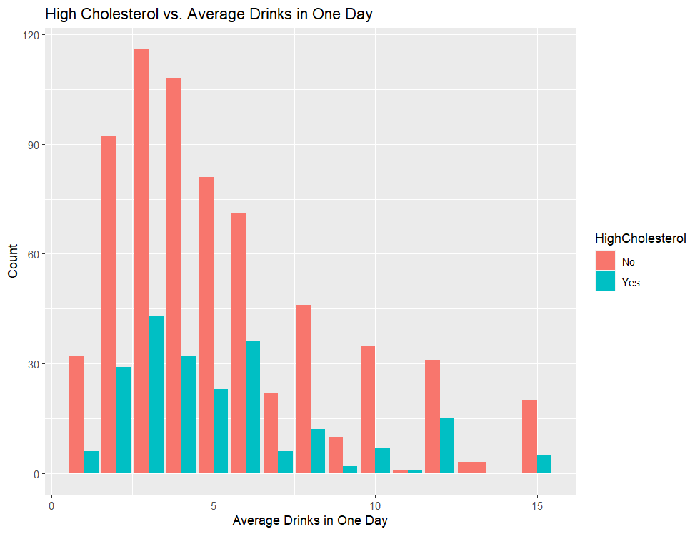

A null hypothesis and alternate hypothesis was created for the two different models.

In Figure 5, the **null hypothesis** was *Gender does not affect blood pressure or cholesterol level* and the **alternate hypothesis** was *Gender does affect blood pressure or cholesterol level*

In Figure 6, the **null hypothesis** was *Having 4 or more drinks does not affect blood pressure or cholesterol level* and the **alternate hypothesis** was *Having 4 or more drinks does affect blood pressure or cholesterol level .*

### Figure 5

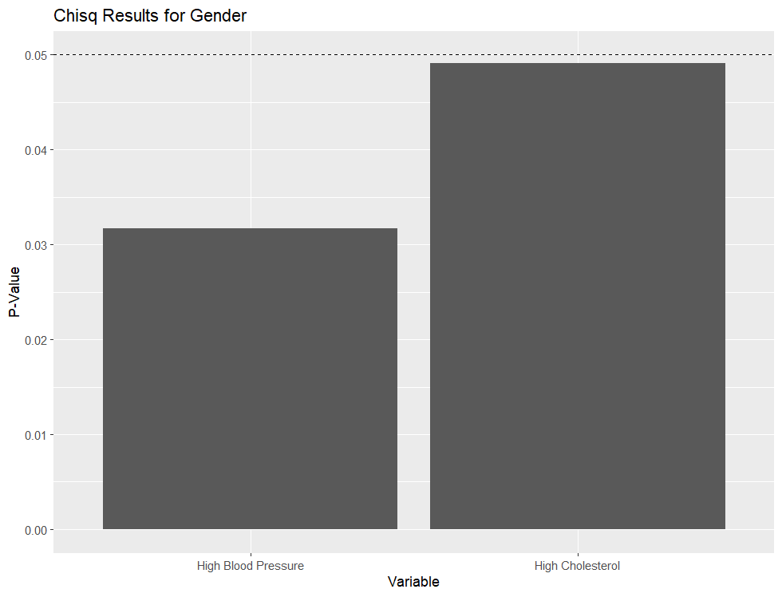

Figure 5 shows the Chi-Square results for the first variable tested. As shown above, both models fell beneath the 0.05, meaning that they reject the null hypothesis. The chi-square model for HighBloodPressure had a p-value of 0.03167844 and the chi-square model for HighCholesterol had a p-value of 0.04909763 .

### Figure 6

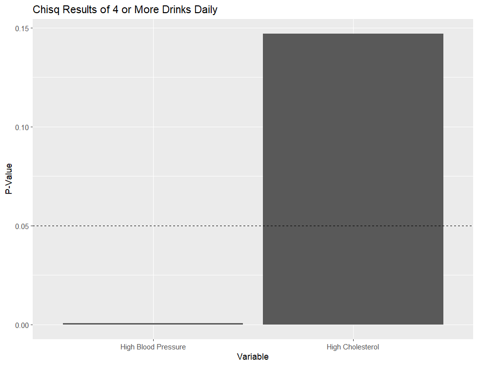

Figure 6 however, shows something different. This chi-square model sought to compare the results of High Blood Pressure/Cholesterol and 4 or More Drinks Daily. However, only High Blood Pressure falls below the 0.05 line and rejects the null hypothesis. The p-value for High Cholesterol is way above it. The chi-square model for HighBloodPressure had a p-value of 0.0006144196 and the chi-square model for HighCholesterol had a p-value of 0.1470252.

## Discussion

Although my initial hypothesis includes the intake of alcohol and its comparison to physical health, and that the second chi-square test did not reject the null hypothesis when testing for high cholesterol, this doesn’t necessarily mean that it is wrong. There could be other factors that affect this.

Due to the use of multiple surveys, this had led to a lot of NA values being produced in the data set upon merging the three data sets together. This is due to some who had taken the high blood pressure/high cholesterol survey and not the alcohol survey or vice verse, meaning the data set had to be cut down a lot. Additionally, I had wished to use more variables and data sets such as weight, kidney health, heart disease, diet and more, as these are also other factors that can contribute to an affect of alcohol or be affected by alcoholic intake. Due to how complex this would be however, I unfortunately did not have enough time within the scope of this project to clean and test all these variables.

In order to better understand the topic at hand, I believe a new survey should be conducted that takes all these variables into account, in addition to more specific questions about alcoholic intake such as differentiating between shots, glasses or bottles, and the type of alcoholic beverage consumed, as all of these may change and affect how results are perceived. All these variables being contained in the same survey also allows for minimal NA values to be present as everyone would have taken the same survey.

Although this may have not been the most concise research into the topic of alcoholic intake and affect on health, it is still important to move forward with research and continue to figure out specifics of the harm of alcohol. Many develop alcohol addictions and end up harming themselves and the people around them, it is important to make people more aware of the dangers of alcohol.

## Acknowledgements

Special thanks to Sarah Mae Parker for teaching me the basic of R, R Studio, and Machine Learning, Tejas Kamtam and Yijia Wang who were my TAs throughout the program that helped out, Delaney Rice for coordinating, and the rest of The Coding School for hosting the Data Science Research Program. I would also like to thank TCS for providing the scholarship that had made it possible for me to learn and participate in this program.

## Extra Links

Listed here are links to the data sets used along with my GitHub. My code is listed under the branch labeled `devJQ` .

[GitHub DSRP 2023 DiDonato](https://github.com/the-codingschool/DSRP-2023-DiDonato)

[CDC Questionnaire Data Sets](https://wwwn.cdc.gov/nchs/nhanes/search/datapage.aspx?Component=Questionnaire&Cycle=2017-2020)

[Demographics Codebook](https://wwwn.cdc.gov/Nchs/Nhanes/2017-2018/P_DEMO.htm)

[Blood Pressure/Cholesterol Codebook](https://wwwn.cdc.gov/Nchs/Nhanes/2017-2018/P_BPQ.htm)

[Alcohol Use Codebook](https://wwwn.cdc.gov/Nchs/Nhanes/2017-2018/P_ALQ.htm)

## Bibliography

*Drinking too much alcohol can harm your health. Learn the facts | CDC*. (2022, April 14). Drinking Too Much Alcohol Can Harm Your Health. Learn the Facts | CDC. https://www.cdc.gov/alcohol/fact-sheets/alcohol-use.htm

*Alcohol-Related Emergencies and Deaths in the United States | National Institute on Alcohol Abuse and Alcoholism (NIAAA)*. (2023, January 1). Alcohol-Related Emergencies and Deaths in the United States | National Institute on Alcohol Abuse and Alcoholism (NIAAA). https://www.niaaa.nih.gov/alcohols-effects-health/alcohol-topics/alcohol-facts-and-statistics/alcohol-related-emergencies-and-deaths-united-states#:~:text=It%20is%20estimated%20that%20more,physical%20inactivity%2C%20and%20illegal%20drugs.

*The American Alcohol Problem: An Overlooked and Deadly Epidemic*. (n.d.). Caron Treatment Centers. https://www.caron.org/blog/the-american-alcohol-problem